# Data analysis - Soft Robot Walker Study

### 6.4.2 run again: EFA for “Bioinspiration Items”

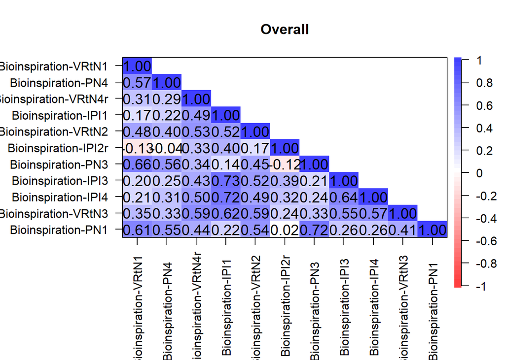

```
#> parallel analysis
```

```r
#### Overall EFA
regExOverall <- "^Bioinspiration"


psych::cor.plot(r = cor(dat[, str_detect(string = colnames(dat),
                                                   pattern = regExOverall)]
                        , use = "pairwise.complete.obs"),
                upper = FALSE, xlas = 2, main = "Overall")
```

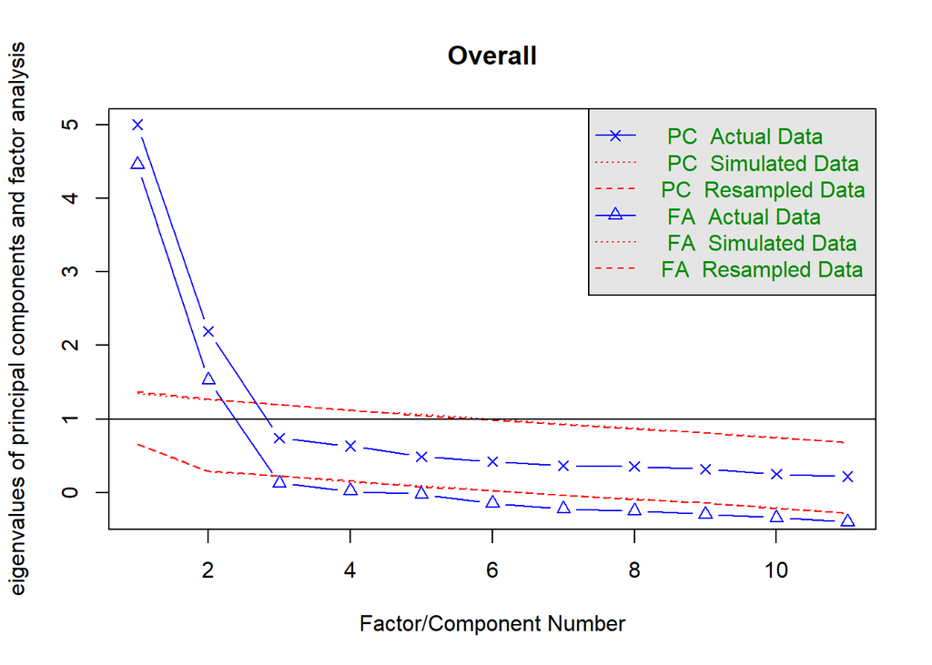

```
Parallel analysis suggests that the number of factors =  2  and the number of components =  2
Overall
Number of components:  2
```

[output not shown]

```r
tmp_parallelAnalysis <- dimensionalityTest(label = "Overall",
                             regEx = regExOverall, dataset = dat)
```

```r
tmp_EFA <- explorativeFactorAnalysis(label = "Overall",
                                 regEx = regExOverall,
                                 dataset = dat, nfac = tmp_parallelAnalysis$nfact)
tmp_EFA[[1]]
```

```
Factor Analysis using method =  minres
Call: fa(r = tmp_dat, nfactors = nfac, rotate = "promax", cor = "cor")
Standardized loadings (pattern matrix) based upon correlation matrix
                        MR1   MR2   h2   u2 com
Bioinspiration-VRtN1  -0.10  0.83 0.63 0.37 1.0
Bioinspiration-PN4     0.02  0.67 0.46 0.54 1.0
Bioinspiration-VRtN4r  0.53  0.25 0.46 0.54 1.4
Bioinspiration-IPI1    0.92 -0.09 0.78 0.22 1.0
Bioinspiration-VRtN2   0.46  0.45 0.58 0.42 2.0
Bioinspiration-IPI2r   0.58 -0.29 0.28 0.72 1.5
Bioinspiration-PN3    -0.13  0.89 0.71 0.29 1.0
Bioinspiration-IPI3    0.79  0.00 0.63 0.37 1.0
Bioinspiration-IPI4    0.76  0.05 0.61 0.39 1.0
Bioinspiration-VRtN3   0.63  0.25 0.59 0.41 1.3
Bioinspiration-PN1     0.01  0.81 0.67 0.33 1.0

                       MR1  MR2
SS loadings           3.36 3.06
Proportion Var        0.31 0.28
Cumulative Var        0.31 0.58
Proportion Explained  0.52 0.48
Cumulative Proportion 0.52 1.00

 With factor correlations of
     MR1  MR2
MR1 1.00 0.41
MR2 0.41 1.00

Mean item complexity =  1.2
Test of the hypothesis that 2 factors are sufficient.

df null model =  55  with the objective function =  6 with Chi Square =  1341.17
df of  the model are 34  and the objective function was  0.29

The root mean square of the residuals (RMSR) is  0.03
The df corrected root mean square of the residuals is  0.04

The harmonic n.obs is  229 with the empirical chi square  26.88  with prob <  0.8
The total n.obs was  229  with Likelihood Chi Square =  64.62  with prob <  0.0012

Tucker Lewis Index of factoring reliability =  0.961
RMSEA index =  0.063  and the 90 % confidence intervals are  0.039 0.086
BIC =  -120.13
Fit based upon off diagonal values = 0.99
Measures of factor score adequacy
                                                   MR1  MR2
Correlation of (regression) scores with factors   0.95 0.95
Multiple R square of scores with factors          0.91 0.90
Minimum correlation of possible factor scores     0.81 0.79
```

## 6.5 Item Response Theory (polytomous) for “Bioinspiration Items”

Factor Loadings (F1) indicate how strongly each item is associated with the latent trait, rule of thumb:

- 0.70 = strong
- 0.40–0.69 = moderate
- < 0.40 = weak

Communality (h²) is the proportion of variance in each item explained by the factor, rule of thumb: + h² > 0.40 → item is well represented + h² < 0.30 → potentially problematic item

```r
if(runIRTmodels){
  # Choose dataset and regular expression
  regEx <- "^Bioinspiration"

  # Filter variables matching the pattern
  irt_items <- dat[, str_detect(colnames(dat), pattern = regEx)]

  # Drop rows with missing data (mirt requires complete cases)
  irt_items <- na.omit(irt_items)

  # Ensure all items are treated as ordered factors
  irt_items[] <- lapply(irt_items, function(x) as.numeric(as.character(x)))
  # Fit Graded Response Model (1-factor)
  mod_grm <- mirt(data = irt_items, model = 1, itemtype = "graded", verbose = FALSE)

  # Summarize model
  summary(mod_grm)


  # Plot Item Characteristic Curves (ICCs) for all items
  plot(mod_grm, type = "trace", facet_items = TRUE, main = "Item Characteristic Curves")

  # Plot Test Information Curve
  plot(mod_grm, type = "info", main = "Test Information Curve: Bioinspiration")



  ### compare results to:
  cor.plot(r = cor(irt_items))
}
```

Compare 1-Factor vs. 2-Factor Models:

```r
if(runIRTmodels){
  mod_1f <- mirt(data = irt_items, model = 1, itemtype = "graded", verbose = FALSE)
  mod_2f <- mirt(data = irt_items, model = 2, itemtype = "graded", verbose = FALSE)
  mod_3f <- mirt(data = irt_items, model = 3, itemtype = "graded", verbose = FALSE)
  anova(mod_1f, mod_2f, mod_3f)

  summary(mod_2f)
summary(mod_3f)
}
```

> significant p-value (e.g., < .05) supports the 2-factor model.

# 7 Compute mean scores

```r
dat$mean_Bioinspiration <- rowMeans(x = dat[,str_subset(colnames(dat), pattern = "^Bioinspiration")])
dat$mean_Bioinspiration_PN <- rowMeans(x = dat[,str_subset(colnames(dat), pattern = "^Bioinspiration-PN")])
dat$mean_Bioinspiration_IPI <- rowMeans(x = dat[,str_subset(colnames(dat), pattern = "^Bioinspiration-IPI")])
dat$mean_Bioinspiration_VRtN <- rowMeans(x = dat[,str_subset(colnames(dat), pattern = "^Bioinspiration-VRtN")])

dat$mean_Ecological <- rowMeans(x = dat[,str_subset(colnames(dat), pattern = "^EcologicalDimension")])


dat$mean_GAToRS_pp <- rowMeans(x = dat[,str_subset(colnames(dat), pattern = "^GAToRS.*pp$")])
dat$mean_GAToRS_pn <- rowMeans(x = dat[,str_subset(colnames(dat), pattern = "^GAToRS.*pn$")])
dat$mean_GAToRS_sp <- rowMeans(x = dat[,str_subset(colnames(dat), pattern = "^GAToRS.*sp$")])
dat$mean_GAToRS_sn <- rowMeans(x = dat[,str_subset(colnames(dat), pattern = "^GAToRS.*sn$")])
```

manifest correlations:

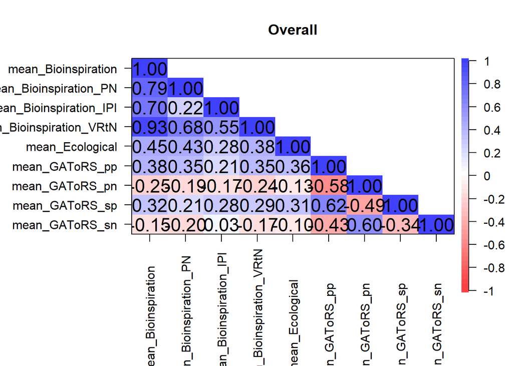

```r
psych::cor.plot(r = cor(dat[, str_detect(string = colnames(dat),
                                                   pattern = "^mean_")]
                        , use = "pairwise.complete.obs"),
                upper = FALSE, xlas = 2, main = "Overall")
```

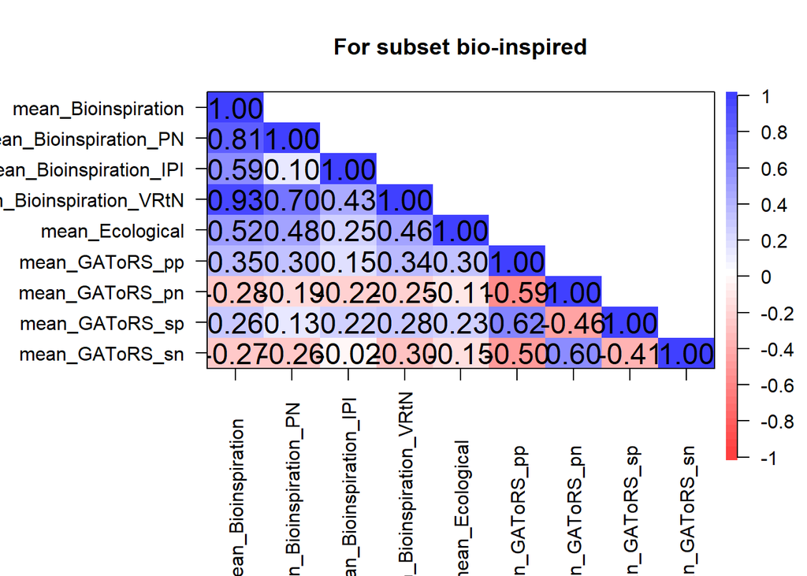

```r
psych::cor.plot(r = cor(dat[dat$framingCondition == "bio-inspired", str_detect(string = colnames(dat),
                                                   pattern = "^mean_")]
                        , use = "pairwise.complete.obs"),
                upper = FALSE, xlas = 2, main = "For subset bio-inspired")
```

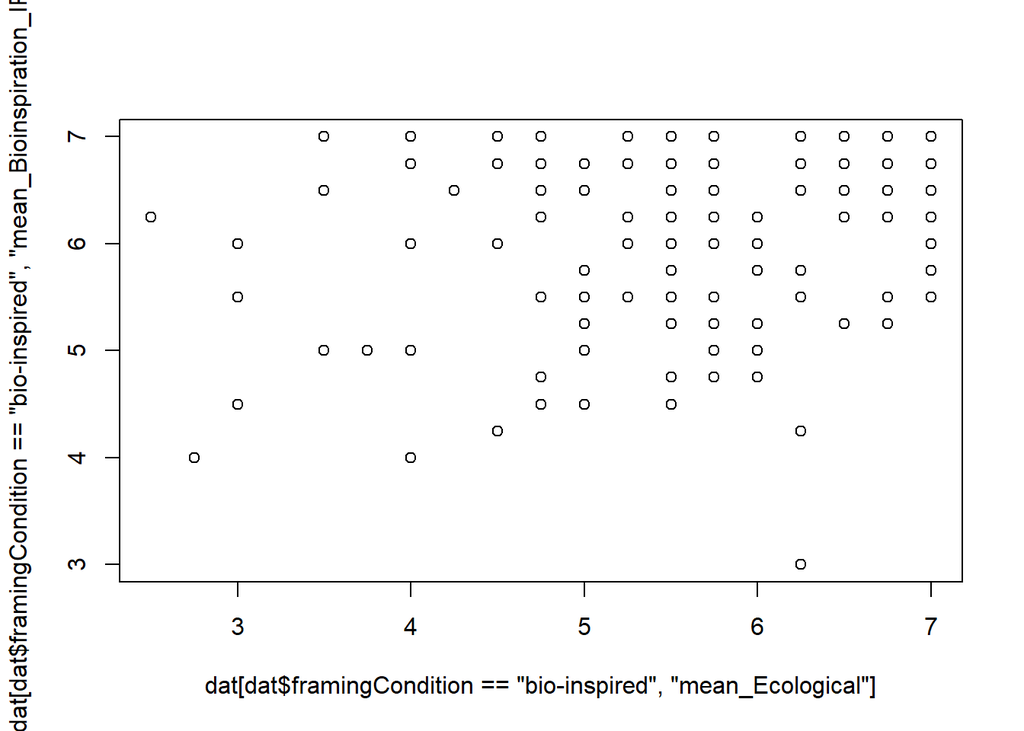

```r
plot(dat[dat$framingCondition == "bio-inspired", "mean_Ecological"], dat[dat$framingCondition == "bio-inspired", "mean_Bioinspiration_IPI"]) # PN most strongly related to sustainability
```

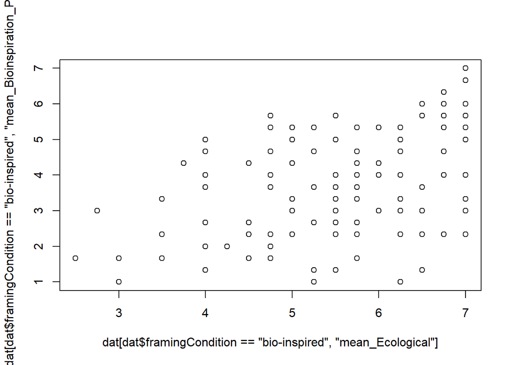

```r
plot(dat[dat$framingCondition == "bio-inspired", "mean_Ecological"], dat[dat$framingCondition == "bio-inspired", "mean_Bioinspiration_PN"])
```

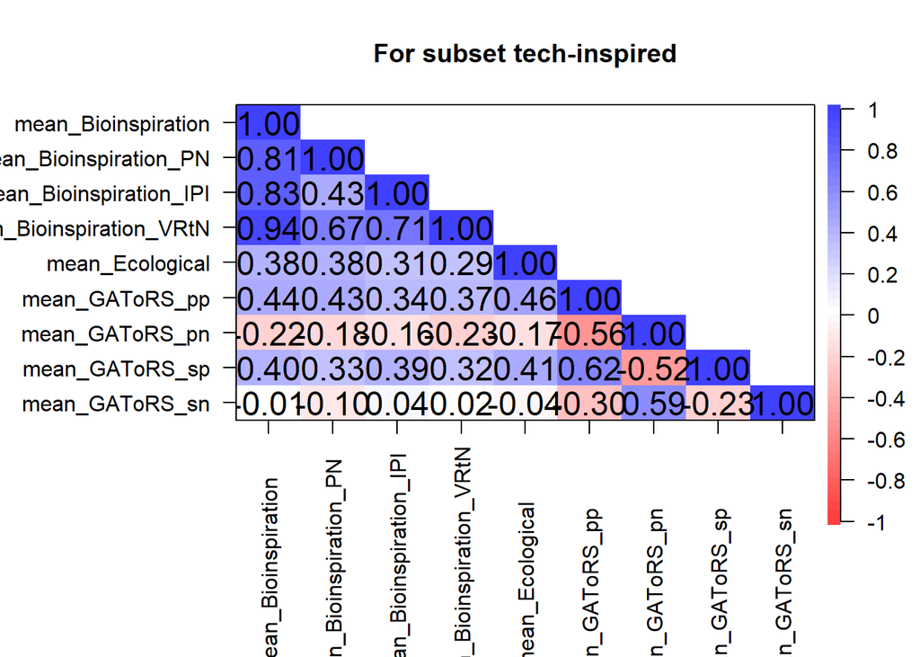

```r
psych::cor.plot(r = cor(dat[dat$framingCondition == "tech-inspired", str_detect(string = colnames(dat),
                                                   pattern = "^mean_")]
                        , use = "pairwise.complete.obs"),
                upper = FALSE, xlas = 2, main = "For subset tech-inspired")
```

```r
dat %>%
  group_by(framingCondition) %>%
  dplyr::summarise(
    N = n(),
    mean_Eco = mean(mean_Ecological, na.rm = TRUE),
    sd_Eco   = sd(mean_Ecological, na.rm = TRUE),

    mean_BioOverall = mean(mean_Bioinspiration, na.rm = TRUE),
    sd_BioOverall   = sd(mean_Bioinspiration, na.rm = TRUE),

    mean_Bio_PN = mean(mean_Bioinspiration_PN, na.rm = TRUE),
    sd_Bio_PN   = sd(mean_Bioinspiration_PN, na.rm = TRUE),

    mean_Bio_IPI = mean(mean_Bioinspiration_IPI, na.rm = TRUE),
    sd_Bio_IPI   = sd(mean_Bioinspiration_IPI, na.rm = TRUE),

    mean_Bio_VRtN = mean(mean_Bioinspiration_VRtN, na.rm = TRUE),
    sd_Bio_VRtN   = sd(mean_Bioinspiration_VRtN, na.rm = TRUE)
  )
```

```
# A tibble: 2 × 12
  framingCondition     N mean_Eco sd_Eco mean_BioOverall sd_BioOverall
  <fct>            <int>    <dbl>  <dbl>           <dbl>         <dbl>
1 bio-inspired       129     5.60   1.08            5.00         0.938
2 tech-inspired      100     5.51   1.17            4.84         1.07
# ℹ 6 more variables: mean_Bio_PN <dbl>, sd_Bio_PN <dbl>, mean_Bio_IPI <dbl>,
#   sd_Bio_IPI <dbl>, mean_Bio_VRtN <dbl>, sd_Bio_VRtN <dbl>
```

# 8 Test Hypotheses

## 8.1 Descriptive

```r
# Summaries of participant-level scores by framing condition
eco_summary <- data_summary(dat, "mean_Ecological", "framingCondition")
bio_summary <- data_summary(dat, "mean_Bioinspiration", "framingCondition")

# View results
print(eco_summary)
```

```
  framingCondition mean_Ecological         se
1     bio-inspired        5.602713 0.09521674
2    tech-inspired        5.512500 0.11679511
```

```r
print(bio_summary)
```

```
  framingCondition mean_Bioinspiration         se
1     bio-inspired            4.995067 0.08260325
2    tech-inspired            4.838182 0.10734430
```

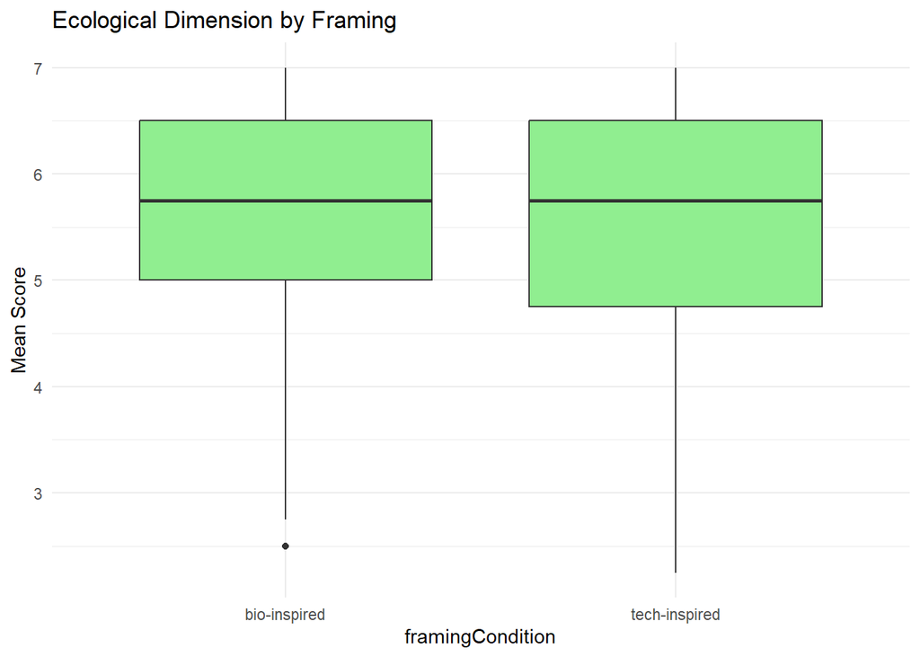

```r
# Plots the mean scores on the Bioinspiration & Ecological Dimension by Framing Condition
ggplot(dat, aes(x = framingCondition, y = mean_Ecological)) +
  geom_boxplot(fill = "lightgreen") +
  labs(title = "Ecological Dimension by Framing", y = "Mean Score") +
  theme_minimal()
```

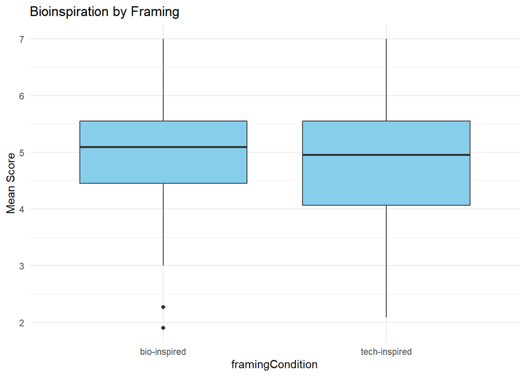

```r
ggplot(dat, aes(x = framingCondition, y = mean_Bioinspiration)) +
  geom_boxplot(fill = "skyblue") +
  labs(title = "Bioinspiration by Framing", y = "Mean Score") +
  theme_minimal()
```